# Aufgabe 07

Christoph Gastmann | Matrikel: 8112863

2024-08-01

# laden der Pakete

```r
library(car)
```

```r
library(ggplot2)
library(tidyverse)
```

1. Lesen Sie die Daten in Lungenlappendichte.csv mithilfe von read.csv2 in einen Data Frame ein und kontrollieren Sie dessen Struktur und Inhalt!

```r
df_lunge <- read.csv2("Lungenlappendichte.csv")
head(df_lunge)
```

```
##   HUDichte LU LO RU RM RO
## 1    -1024  0  7  0 14 16
## 2    -1023  0 12  0 22 32
## 3    -1022  1 13  0 11 19
## 4    -1021  0  9  0  4 19
## 5    -1020  0 15  0 10 33
## 6    -1019  2  5  0 11 36
```

```r
tail(df_lunge)
```

```
##      HUDichte LU LO RU RM RO
## 4070     3045  0  0  0  0  0
## 4071     3046  0  0  0  0  0
## 4072     3047  0  0  0  0  0
## 4073     3048  0  0  0  0  0
## 4074     3049  0  0  0  0  0
## 4075     3050  0  0  0  0  1
```

```r
str(df_lunge)
```

```
## 'data.frame':    4075 obs. of  6 variables:
##  $ HUDichte: int  -1024 -1023 -1022 -1021 -1020 -1019 -1018 -1017 -1016 -1015 ...
##  $ LU      : int  0 0 1 0 0 2 0 1 3 2 ...
##  $ LO      : int  7 12 13 9 15 5 8 3 7 4 ...
##  $ RU      : int  0 0 0 0 0 0 0 0 0 0 ...
##  $ RM      : int  14 22 11 4 10 11 3 7 6 9 ...
##  $ RO      : int  16 32 19 19 33 36 18 32 27 19 ...
```

```r
sample_n(df_lunge, 5)
```

```
##   HUDichte   LU   LO   RU   RM   RO
## 1      535    3    1    0    0    1
## 2      764    0    0    0    0    0
## 3     -857 1734 1821 2390 1179 1462
## 4     2536    0    0    0    0    0
## 5      630    0    0    0    0    0
```

```r
view(df_lunge)
```

2. Leiten Sie eine neue Spalte Gesamt ab, die f¨ur jeden HU-Wert seine ¨uber die f¨unf Lungenlappen hinweg kumulierte Gesamth¨aufigkeit enth¨alt!

```r
df_lunge$Gesamt <- rowSums(df_lunge[, c("LU", "LO", "RU", "RM", "RO")])
view(df_lunge)
```

3. Die Aufl¨osung der HU-Skala soll vergr¨obert werden, damit die H¨aufigkeitsverteilung der in Spalte Gesamt stehenden Daten ¨uberhaupt einigermaßen ¨ubersichtlich wird. Leiten Sie zu diesem Zweck mithilfe der Funktion cut zun¨achst einen Faktorvektor aus der Spalte HUDichte ab, wobei Sie ihren Wertebereich von -1100 bis 3100 in Intervalle der Breite 100 einteilen! Sorgen Sie daf¨ur, dass der Faktorvektor den ad¨aquaten Modus einer ordinal skalierten Variablen hat! (2 Punkte) Nutzen Sie dann jenen Faktorvektor, um die Elemente der Spalte Gesamt entsprechend gruppiert zu summieren! (Tipp: tapply in Verbindung mit sum.)

```r
df_lunge$HUCut <- cut(df_lunge$HUDichte, breaks = seq(-1100, 3100, by = 100), right = FALSE)
df_lunge$HUCut <- factor(df_lunge$HUCut, ordered = TRUE)

gesamt_gruppiert <- tapply(df_lunge$Gesamt, df_lunge$HUCut, sum, na.rm = TRUE)
gesamt_gruppiert
```

```
## [-1.1e+03,-1e+03)     [-1e+03,-900)       [-900,-800)       [-800,-700)
##               829             12500           1397291           1509047
##       [-700,-600)       [-600,-500)       [-500,-400)       [-400,-300)
##            302545            134313             90041             66411
##       [-300,-200)       [-200,-100)          [-100,0)           [0,100)
##             22973             16759             14056             12592
##         [100,200)         [200,300)         [300,400)         [400,500)
##             10281              9239             12552              8596
##         [500,600)         [600,700)         [700,800)         [800,900)
##               598                57                44                34
##       [900,1e+03)   [1e+03,1.1e+03) [1.1e+03,1.2e+03) [1.2e+03,1.3e+03)
##                29                28                29                28
## [1.3e+03,1.4e+03) [1.4e+03,1.5e+03) [1.5e+03,1.6e+03) [1.6e+03,1.7e+03)
##                27                23                17                28
## [1.7e+03,1.8e+03) [1.8e+03,1.9e+03)   [1.9e+03,2e+03)   [2e+03,2.1e+03)
##                10                11                 6                 5
## [2.1e+03,2.2e+03) [2.2e+03,2.3e+03) [2.3e+03,2.4e+03) [2.4e+03,2.5e+03)
##                10                 4                 2                 3
## [2.5e+03,2.6e+03) [2.6e+03,2.7e+03) [2.7e+03,2.8e+03) [2.8e+03,2.9e+03)
##                 2                 3                 1                 1
##   [2.9e+03,3e+03)   [3e+03,3.1e+03)
##                 2                 1
```

4. Fertigen Sie schließlich f¨ur die ”gruppierte“ H¨aufigkeitsverteilung von eben ein S¨aulendiagramm mit horizontalen S¨aulen an (also ein Balkendiagramm)! Sorgen Sie mit den Argumenten las und mar der Funktion par daf¨ur, dass die Beschriftung beider Achsen 3 horizontal ist und dass insbesondere f¨ur die Beschriftung der vertikalen Achse gen¨ugend Platz ist! Charakterisieren Sie kurz die dargestellte Verteilung!

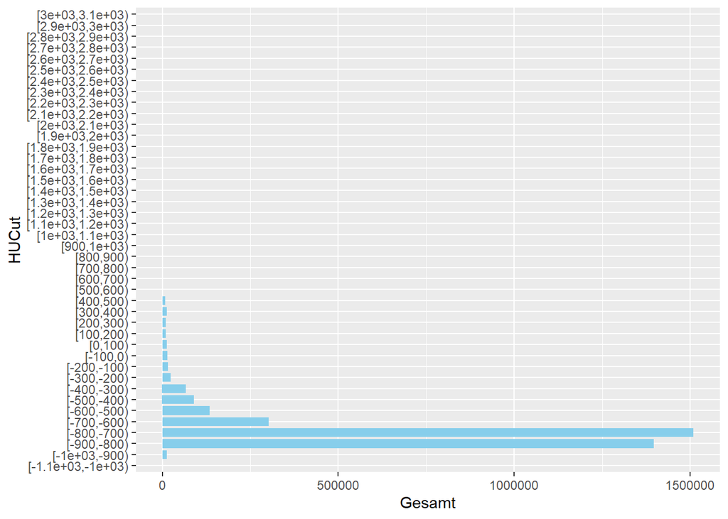

```r
par(mar=c(5.1, 12, 4.1, 2.1), las=1)
ggplot(df_lunge, aes(Gesamt, HUCut)) + geom_col(width = 0.8, fill = "skyblue")
```

5. Rekonstruieren Sie aus den vorliegenden H¨aufigkeiten in Gesamt und den dazugeh¨origen Werten in HUDichte die urspr¨unglichen Rohdaten! (Es sollte ein Vektor mit mehr als 3,6 Mio. Elementen sein.)

```r
werte_lunge_roh <- rep(df_lunge$HUDichte, df_lunge$Gesamt)
laenge_lunge_roh <- length(werte_lunge_roh)
laenge_lunge_roh
```

```
## [1] 3621028
```

6. Einen Normal-QQ-Plot f¨ur eine derart große Stichprobe wie die in Teil e rekonstruierte anzufertigen, ist aufgrund der Rechenzeit sinnlos. Alternativ kann man eine (oder mehrere) hinreichend große, zuf¨allige Teilstichprobe(n) aus der Stichprobe ziehen und f¨ur diese die Zul¨assigkeit der Normalverteilungsannahme pr¨ufen. Ziehen Sie mithilfe der Funktion sample (siehe ihre Hilfeseite!) reproduzierbar (!) etwa 0,5 % der Stichprobe von Teil e als zuf¨allige Teilstichprobe und beurteilen Sie daf¨ur, ob die Normalverteilungsannahme haltbar ist!

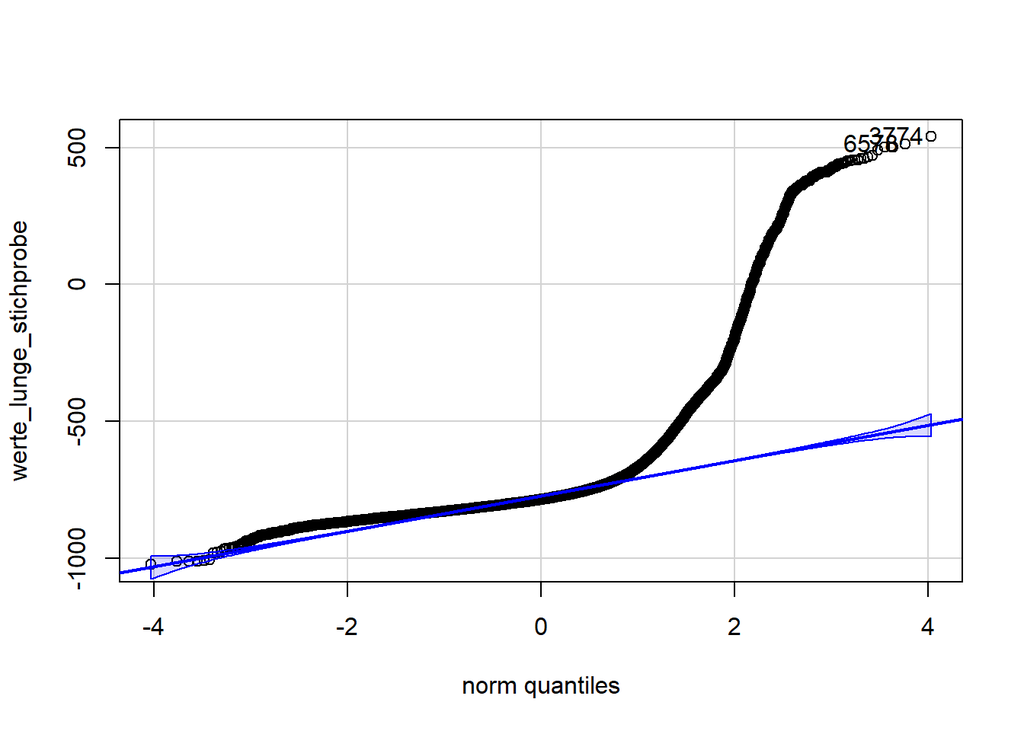

```
## [1] 3774 6578
```

```r
set.seed(42)
werte_lunge_stichprobe <- sample(werte_lunge_roh, size = laenge_lunge_roh * 0.005)
qqPlot(werte_lunge_stichprobe)
```

Die Stichprobe weicht deutlich von der Normalverteilung ab, insbesondere für positive Werte.